# Bellabeat Case Study

Kane M

2023-02-03

## Setting Up My Environment

Notes: Setting up my environment by loading the ‘tidyverse’, ‘lubridate’, ‘here’, ‘janitor’, and ‘skimr’ packages.

```r
library(tidyverse)
library(lubridate)
library(here)
library(skimr)
library(janitor)
```

## Importing the Datasets

```r
daily_activity <- read.csv("Bellabeat Project/dailyActivity_merged.csv")
daily_sleep <- read.csv("Bellabeat Project/sleepDay_merged.csv")
weight_log <- read.csv("Bellabeat Project/weightLogInfo_merged.csv")
```

#### Double Checking Datasets

```r
##daily_activity
head(daily_activity)
```

```
##           Id ActivityDate TotalSteps TotalDistance TrackerDistance
## 1 1503960366    4/12/2016      13162          8.50            8.50
## 2 1503960366    4/13/2016      10735          6.97            6.97
## 3 1503960366    4/14/2016      10460          6.74            6.74
## 4 1503960366    4/15/2016       9762          6.28            6.28
## 5 1503960366    4/16/2016      12669          8.16            8.16
## 6 1503960366    4/17/2016       9705          6.48            6.48
##   LoggedActivitiesDistance VeryActiveDistance ModeratelyActiveDistance
## 1                        0               1.88                     0.55
## 2                        0               1.57                     0.69
## 3                        0               2.44                     0.40
## 4                        0               2.14                     1.26
## 5                        0               2.71                     0.41
## 6                        0               3.19                     0.78
##   LightActiveDistance SedentaryActiveDistance VeryActiveMinutes
## 1                6.06                       0                25
## 2                4.71                       0                21
## 3                3.91                       0                30
## 4                2.83                       0                29
## 5                5.04                       0                36
## 6                2.51                       0                38
##   FairlyActiveMinutes LightlyActiveMinutes SedentaryMinutes Calories
## 1                  13                  328              728     1985
## 2                  19                  217              776     1797
## 3                  11                  181             1218     1776
## 4                  34                  209              726     1745
## 5                  10                  221              773     1863
## 6                  20                  164              539     1728
```

```r
colnames(daily_activity)
```

```
##  [1] "Id"                       "ActivityDate"
##  [3] "TotalSteps"               "TotalDistance"
##  [5] "TrackerDistance"          "LoggedActivitiesDistance"
##  [7] "VeryActiveDistance"       "ModeratelyActiveDistance"
##  [9] "LightActiveDistance"      "SedentaryActiveDistance"
## [11] "VeryActiveMinutes"        "FairlyActiveMinutes"
## [13] "LightlyActiveMinutes"     "SedentaryMinutes"
## [15] "Calories"
```

```r
##daily_sleep
head(daily_sleep)
```

```
##           Id              SleepDay TotalSleepRecords TotalMinutesAsleep
## 1 1503960366 4/12/2016 12:00:00 AM                 1                327
## 2 1503960366 4/13/2016 12:00:00 AM                 2                384
## 3 1503960366 4/15/2016 12:00:00 AM                 1                412
## 4 1503960366 4/16/2016 12:00:00 AM                 2                340
## 5 1503960366 4/17/2016 12:00:00 AM                 1                700
## 6 1503960366 4/19/2016 12:00:00 AM                 1                304
##   TotalTimeInBed
## 1            346
## 2            407
## 3            442
## 4            367
## 5            712
## 6            320
```

```r
colnames(daily_sleep)
```

```
## [1] "Id"                 "SleepDay"           "TotalSleepRecords"
## [4] "TotalMinutesAsleep" "TotalTimeInBed"
```

```r
##weight_log
head(weight_log)
```

```
##           Id                  Date WeightKg WeightPounds Fat   BMI
## 1 1503960366  5/2/2016 11:59:59 PM     52.6     115.9631  22 22.65
## 2 1503960366  5/3/2016 11:59:59 PM     52.6     115.9631  NA 22.65
## 3 1927972279  4/13/2016 1:08:52 AM    133.5     294.3171  NA 47.54
## 4 2873212765 4/21/2016 11:59:59 PM     56.7     125.0021  NA 21.45
## 5 2873212765 5/12/2016 11:59:59 PM     57.3     126.3249  NA 21.69
## 6 4319703577 4/17/2016 11:59:59 PM     72.4     159.6147  25 27.45
##   IsManualReport        LogId
## 1           True 1.462234e+12
## 2           True 1.462320e+12
## 3          False 1.460510e+12
## 4           True 1.461283e+12
## 5           True 1.463098e+12
## 6           True 1.460938e+12
```

```r
colnames(weight_log)
```

```
## [1] "Id"             "Date"           "WeightKg"       "WeightPounds"
## [5] "Fat"            "BMI"            "IsManualReport" "LogId"
```

## Data Cleaning

Checking for and removing any duplicates from the datasets.

```r
sum(duplicated(daily_activity))
```

```
## [1] 0
```

```r
sum(duplicated(daily_sleep))
```

```
## [1] 3
```

```r
sum(duplicated(weight_log))
```

```
## [1] 0
```

Three duplicates came up in the ‘daily_sleep’ dataset and were removed.

```r
dailySleep_cleaned <- unique(daily_sleep)
sum(duplicated(dailySleep_cleaned))
```

```
## [1] 0
```

To make the data frames easier to merge later, I changed the ‘ActivityDate’ and ‘SleepDay’ columns in ‘daily_activity’ and ‘daily_sleep’ respectively to simply be ‘Date’. I also reformatted ‘Date’ in each dataset.

```r
dailyActivity_cleaned <- daily_activity %>%
  rename(Date = ActivityDate) %>%
  mutate(Date = mdy(Date))
dailySleep_cleaned <- dailySleep_cleaned %>%
  rename(Date = SleepDay) %>%
  mutate(Date = mdy_hms(Date))

weightLog_cleaned <- weight_log %>%
  mutate(Date = mdy_hms(Date))

##double check changes
str(dailyActivity_cleaned)
```

```
## 'data.frame':    940 obs. of  15 variables:
##  $ Id                      : num  1.5e+09 1.5e+09 1.5e+09 1.5e+09 1.5e+09 ...
##  $ Date                    : Date, format: "2016-04-12" "2016-04-13" ...
##  $ TotalSteps              : int  13162 10735 10460 9762 12669 9705 13019 15506 10544 9819 ...
##  $ TotalDistance           : num  8.5 6.97 6.74 6.28 8.16 ...
##  $ TrackerDistance         : num  8.5 6.97 6.74 6.28 8.16 ...
##  $ LoggedActivitiesDistance: num  0 0 0 0 0 0 0 0 0 0 ...
##  $ VeryActiveDistance      : num  1.88 1.57 2.44 2.14 2.71 ...
##  $ ModeratelyActiveDistance: num  0.55 0.69 0.4 1.26 0.41 ...
##  $ LightActiveDistance     : num  6.06 4.71 3.91 2.83 5.04 ...
##  $ SedentaryActiveDistance : num  0 0 0 0 0 0 0 0 0 0 ...
##  $ VeryActiveMinutes       : int  25 21 30 29 36 38 42 50 28 19 ...
##  $ FairlyActiveMinutes     : int  13 19 11 34 10 20 16 31 12 8 ...
##  $ LightlyActiveMinutes    : int  328 217 181 209 221 164 233 264 205 211 ...
##  $ SedentaryMinutes        : int  728 776 1218 726 773 539 1149 775 818 838 ...
##  $ Calories                : int  1985 1797 1776 1745 1863 1728 1921 2035 1786 1775 ...
```

```r
str(dailySleep_cleaned)
```

```
## 'data.frame':    410 obs. of  5 variables:
##  $ Id                : num  1.5e+09 1.5e+09 1.5e+09 1.5e+09 1.5e+09 ...
##  $ Date              : POSIXct, format: "2016-04-12" "2016-04-13" ...
##  $ TotalSleepRecords : int  1 2 1 2 1 1 1 1 1 1 ...
##  $ TotalMinutesAsleep: int  327 384 412 340 700 304 360 325 361 430 ...
##  $ TotalTimeInBed    : int  346 407 442 367 712 320 377 364 384 449 ...
```

```r
str(weightLog_cleaned)
```

```
## 'data.frame':    67 obs. of  8 variables:
##  $ Id            : num  1.50e+09 1.50e+09 1.93e+09 2.87e+09 2.87e+09 ...
##  $ Date          : POSIXct, format: "2016-05-02 23:59:59" "2016-05-03 23:59:59" ...
##  $ WeightKg      : num  52.6 52.6 133.5 56.7 57.3 ...
##  $ WeightPounds  : num  116 116 294 125 126 ...
##  $ Fat           : int  22 NA NA NA NA 25 NA NA NA NA ...
##  $ BMI           : num  22.6 22.6 47.5 21.5 21.7 ...
##  $ IsManualReport: chr  "True" "True" "False" "True" ...
##  $ LogId         : num  1.46e+12 1.46e+12 1.46e+12 1.46e+12 1.46e+12 ...
```

Next, I checked for inconsistent or missing entries.

```r
sum(is.na(dailyActivity_cleaned))
```

```
## [1] 0
```

```r
sum(is.na(dailySleep_cleaned))
```

```
## [1] 0
```

```r
sum(is.na(weightLog_cleaned))
```

```
## [1] 65
```

```r
## there are 65 values missing in weightLog_cleaned

colSums(is.na(weightLog_cleaned))
```

```
##             Id           Date       WeightKg   WeightPounds            Fat
##              0              0              0              0             65
##            BMI IsManualReport          LogId
##              0              0              0
```

```r
nrow(weightLog_cleaned)
```

```
## [1] 67
```

```r
## all missing values are from the 'Fat' column. There also 67 rows available in 'weightLog_cleaned'
## meaning that only 2 values are in 'Fat'. Because this is a third party dataset, it can not be determined
## what thhese values were supposed to be. Because of this and the column not being needed for my analysis,
## 'Fat' will be removed.

weightLog_cleaned <- weightLog_cleaned[, -5]

## confirming removal of 'Fat'

colnames(weightLog_cleaned)
```

```
## [1] "Id"             "Date"           "WeightKg"       "WeightPounds"
## [5] "BMI"            "IsManualReport" "LogId"
```

```r
colSums(is.na(weightLog_cleaned))
```

```
##             Id           Date       WeightKg   WeightPounds            BMI
##              0              0              0              0              0
## IsManualReport          LogId
##              0              0
```

```r
## there is more user data logged in dailyActivity than both dailySleep and weightLog

n_distinct(dailyActivity_cleaned$Id)
```

```
## [1] 33
```

```r
n_distinct(dailySleep_cleaned$Id)
```

```
## [1] 24
```

```r
n_distinct(weightLog_cleaned$Id)
```

```
## [1] 8
```

```r
## there are a few of columns with zero values in dailyActivity, which can not be possible
## given the data logged. In order to eliminate any potential bias, rows with these values will be removed

dailyActivity_cleaned  <- dailyActivity_cleaned %>%
  filter(TotalSteps > 0, Calories > 0, TotalDistance  > 0)

## confirm changes

sum(dailyActivity_cleaned$TotalSteps <= 0)
```

```
## [1] 0
```

```r
sum(dailyActivity_cleaned$Calories <= 0)
```

```
## [1] 0
```

```r
sum(dailyActivity_cleaned$TotalDistance <= 0)
```

```
## [1] 0
```

```r
## there is no need to make changes to weightLog and dailySleep because there are no zero values
```

After my final edits to the data frames, I checked the number of rows left.

```r
nrow(dailyActivity_cleaned)
```

```
## [1] 862
```

```r
nrow(dailySleep_cleaned)
```

```
## [1] 410
```

```r
nrow(weightLog_cleaned)
```

```
## [1] 67
```

## Summarizing the Data

```
##    TotalSteps    TotalDistance       Calories    SedentaryMinutes
##  Min.   :    8   Min.   : 0.010   Min.   :  52   Min.   :   0.0
##  1st Qu.: 4927   1st Qu.: 3.373   1st Qu.:1857   1st Qu.: 721.2
##  Median : 8054   Median : 5.590   Median :2220   Median :1020.5
##  Mean   : 8329   Mean   : 5.986   Mean   :2362   Mean   : 955.2
##  3rd Qu.:11096   3rd Qu.: 7.905   3rd Qu.:2832   3rd Qu.:1189.0
##  Max.   :36019   Max.   :28.030   Max.   :4900   Max.   :1440.0
```

```
##  TotalSleepRecords TotalMinutesAsleep TotalTimeInBed
##  Min.   :1.00      Min.   : 58.0      Min.   : 61.0
##  1st Qu.:1.00      1st Qu.:361.0      1st Qu.:403.8
##  Median :1.00      Median :432.5      Median :463.0
##  Mean   :1.12      Mean   :419.2      Mean   :458.5
##  3rd Qu.:1.00      3rd Qu.:490.0      3rd Qu.:526.0
##  Max.   :3.00      Max.   :796.0      Max.   :961.0
```

```
##       BMI           WeightKg
##  Min.   :21.45   Min.   : 52.60
##  1st Qu.:23.96   1st Qu.: 61.40
##  Median :24.39   Median : 62.50
##  Mean   :25.19   Mean   : 72.04
##  3rd Qu.:25.56   3rd Qu.: 85.05
##  Max.   :47.54   Max.   :133.50
```

### Findings

Average Steps: 8329 (below daily recommendation)

Average Distance: 5.986km

Average Calories Burned: 2362/day

Average Sedentary Minutes: 955.2 (about 16 hours)

Average Sleep Time: 419.2 minutes (about 7 hours)

Average Weight: 72.04kg

Notable Outlier: One user only reported one instance of sleeping for an hour but logged 31 days of activity.

Findings are subject to bias because the gender of participants was not specified and we do not have enough data.

## Visulaizing the Data

I need to merge the dataframes in order to draw deeper conclusions and create my visualizations.

```r
final_dailySleep <- merge(dailyActivity_cleaned, dailySleep_cleaned, by= c("Id", "Date"))
final_dailyWeight <- merge(dailyActivity_cleaned, weightLog_cleaned, by= c("Id", "Date"))
```

#### Steps vs Calories

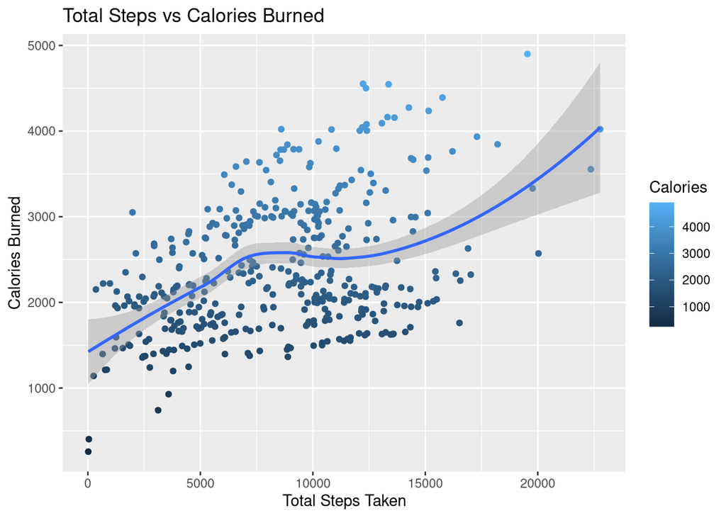

#### Idle Activity vs Calories

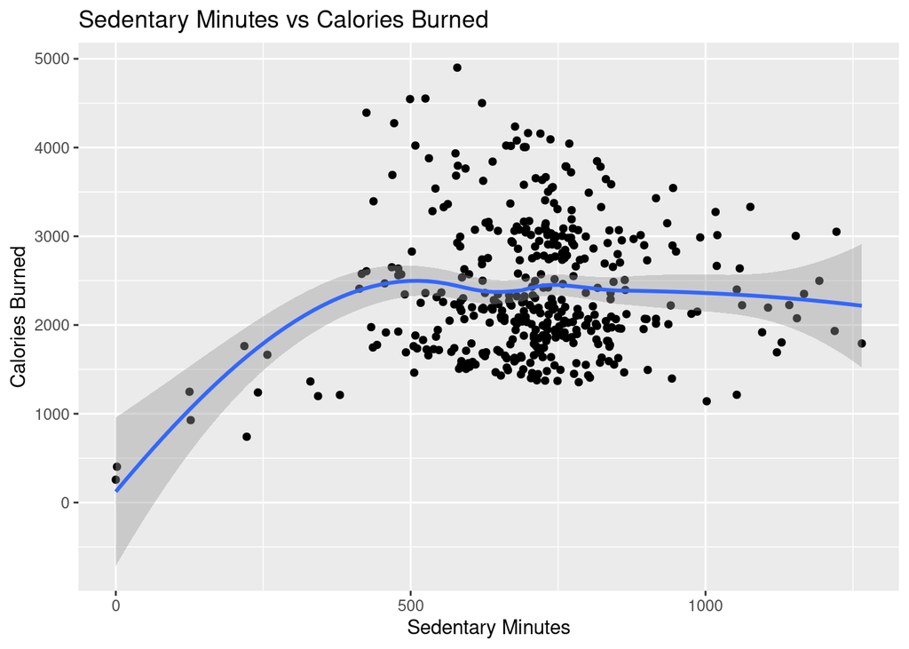

No conclusive evidence of the inverse can be drawn from this comparison.

#### Activity vs Body Mass Index (BMI)

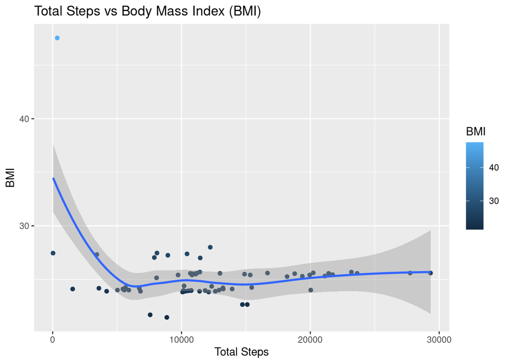

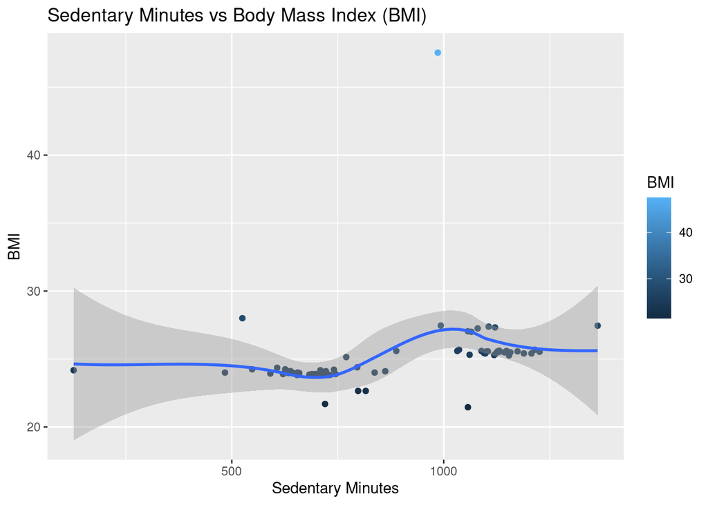

#### Idle Activity vs Time Spent Sleeping

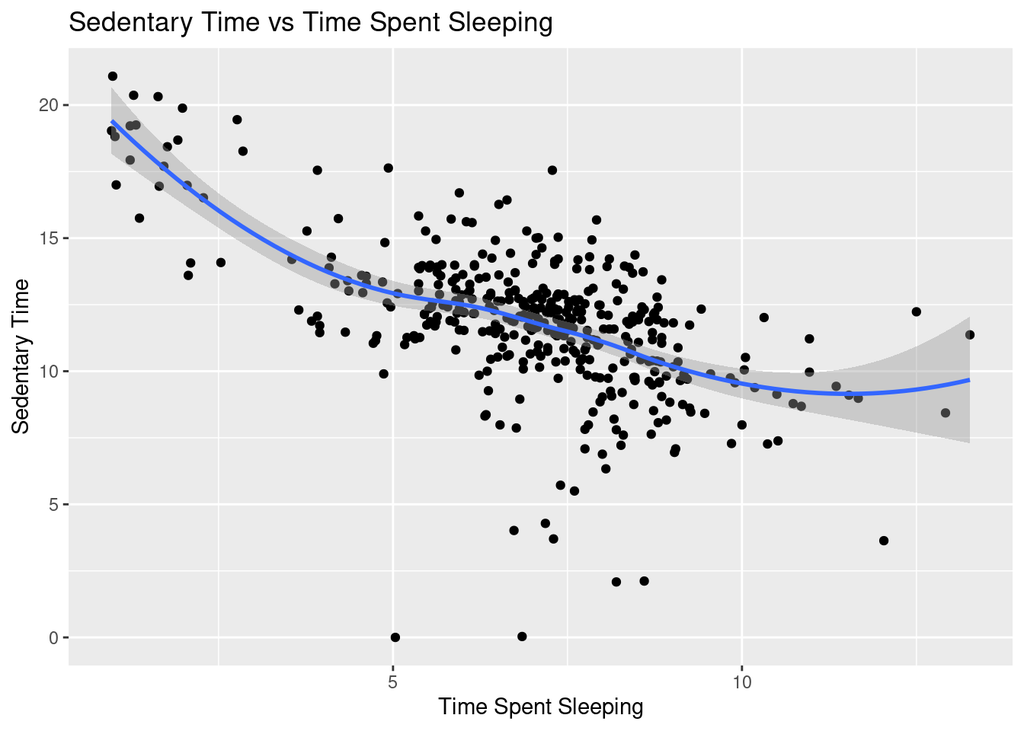

## Conclusion

#### Sleep

Sleep: The average amount of time spent sleeping is about 7 hours, which is good! But without considering health conditions which could affect one’s sleep and the age group of our entrants not being specified, the data is biased.

1. Incentives for reaching goals to drive engagement
- Set daily steps goals and weekly activity goals. Remind ALL users, not just obese or overweight ones.
- Reward users with points which can be redeemed for gift cards, wellness products and accessories, or leisurely activities such as spa visits.
2. Reinforce set goals and motivate users
- Sedentary lifestyles can be the result of one’s job, so you can also add reminders to get up and take short walking breaks.
- Sleep is just as important as physical activity in monitoring one’s health. As such, we can advise users on sleep schedules to keep them on track with
- their goals and allow them to add personalized alarms to reach said goals.

+Adding a weight log can also help drive interaction with the Bellabeat app. Tracking one’s weight is another important factor in monitoring their health.